# GRAD 695 Executive Class

Qiulin Peng

## Introduction

We are using the Income dataset and try to answer the research question, so we first explore the dataset to have dataset overview.

```r
nrow(income)
```

```
## [1] 535
```

```r
summary(income)
```

```
##                                           Occupation
##  Accountants and auditors                      :  1
##  Actors                                        :  1
##  Actuaries                                     :  1
##  Adhesive bonding machine operators and tenders:  1
##  Administrative services managers              :  1
##  Advertising and promotions managers           :  1
##  (Other)                                       :529
##                     Industry    All_workers       All_weekly
##  Production             : 81   Min.   :   0.0   Min.   : 354.0
##  Office                 : 52   1st Qu.:  20.0   1st Qu.: 623.0
##  Construction           : 40   Median :  63.0   Median : 859.0
##  Maintenance            : 37   Mean   : 203.9   Mean   : 912.9
##  Transportation         : 36   3rd Qu.: 190.0   3rd Qu.:1122.5
##  Healthcare Professional: 33   Max.   :2806.0   Max.   :2041.0
##  (Other)                :256                    NA's   :236
##    M_workers         M_weekly      F_workers          F_weekly
##  Min.   :   0.0   Min.   : 389   Min.   :   0.00   Min.   : 380.0
##  1st Qu.:  11.0   1st Qu.: 678   1st Qu.:   2.50   1st Qu.: 544.0
##  Median :  32.0   Median : 924   Median :  16.00   Median : 737.0
##  Mean   : 113.5   Mean   :1006   Mean   :  90.31   Mean   : 809.4
##  3rd Qu.: 100.5   3rd Qu.:1264   3rd Qu.:  68.50   3rd Qu.: 986.0
##  Max.   :2582.0   Max.   :2251   Max.   :2262.00   Max.   :1836.0
##                   NA's   :326                      NA's   :366
```

We see that we have 535 records and 8 variables.

An interesting question will be: Are there any difference in income of people from different industries?

## Exploratory Data Analysis

### Correlation between Numeric Variables

```r
numeric_var <- c("All_workers","All_weekly","M_workers","M_weekly","F_workers","F_weekly")
numeric_df <- income[numeric_var]
cor(numeric_df)
```

```
##             All_workers All_weekly M_workers M_weekly F_workers F_weekly
## All_workers   1.0000000         NA 0.8336395       NA 0.8318677       NA
## All_weekly           NA          1        NA       NA        NA       NA
## M_workers     0.8336395         NA 1.0000000       NA 0.3869630       NA
## M_weekly             NA         NA        NA        1        NA       NA
## F_workers     0.8318677         NA 0.3869630       NA 1.0000000       NA
## F_weekly             NA         NA        NA       NA        NA        1
```

Weekly income data have more than half are missing value, so we focus on the worker income variables. It shows that All_worker is highly correlated (>0.83) with M_workers and F_workers, and it suggests that if we include both All_workers and M_workers/F_workers in the model, there will be multilinearity issue. We also see that correlation coefficient between M_worker and F_workers is about 0.39, and it does not have high correlation. Therefore, we will include M_workers and F_workers or All_workers only as numeric variables.

### ANOVA Test of Industry Income

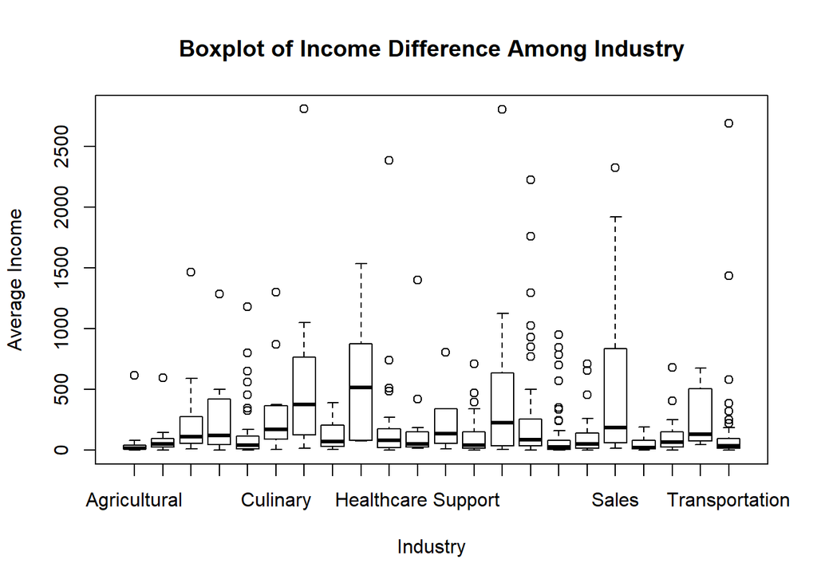

```r
boxplot(income$All_workers~income$Industry, main='Boxplot of Income Difference Among Industry', xlab='Industry', ylab='Average Income')
```

The boxplot shows that the mean income varies among industry. ANOVA test results show that p-value < 0.05, therefore we reject the null hypothesis that the mean incomes are the same among industries, and can conclude that the there are significant differences in mean income among different industries.

```r
summary(aov(All_workers~Industry, data = income))
```

```
##              Df   Sum Sq Mean Sq F value   Pr(>F)
## Industry     21  9415045  448335   3.405 6.93e-07 ***
## Residuals   513 67556442  131689
## ---
## Signif. codes:  0 '***' 0.001 '**' 0.01 '*' 0.05 '.' 0.1 ' ' 1
```

### Gender Income Difference

```r
t.test(income$M_workers,income$F_workers)
```

```
##
##  Welch Two Sample t-test
##
## data:  income$M_workers and income$F_workers
## t = 1.6672, df = 1068, p-value = 0.09578
## alternative hypothesis: true difference in means is not equal to 0
## 95 percent confidence interval:
##  -4.111553 50.578843
## sample estimates:
## mean of x mean of y
## 113.54579  90.31215
```

The t-test results show that, the mean income for males worker is $113, and mean income for female worker is $90. However the p-value = 0.09 > 0.05, so we cannot reject the null hypothesis, and it means we can conclude that there’s no significant difference of mean income between gender.